# RARE Pollen Data Analysis

Jeffrey Minucci

January 23, 2018

# Introduction

Analysis of 2015 rare data collected by Ohio State

**Overall goals**

With May sampling period:

1. Determine whether greater neonic concentrations in pollen were associated with greater bee mortality
2. Determine if neonic concentrations observed were related to the percent coverage of corn nearby.

With the April - August hive health data:

3. Examine whether greater neonic exposure in May was linked to long term consequences for hive health.

Some technical points:

1. In the original April - August hive health dataset, neonic exposure in May (and in planting period) was expressed as sum of the concentrations detected at each sampling date. It would be more appropriate to take the mean of these concentrations. This should make these values easier to interpret. **Note:** this should not change the results, as each site had the same number of measurements during each period. However, if this were not true (for example, if we remove an outlier observation), taking sums would lead to erroneous differences between sites.
2. We removed one field pollen measurement (site FSR, date 5/2/2015, sample # FP-13) which had very high clothianidin and thiamethoxam concentrations. By removing this single observation, we were able to keep site FSR in our hive health analysis without biasing our results.
3. To examine hive health through time, we calculated *relative* changes over each time interval (as % change from the initial value). These relative changes may be more meaningful than absolute changes, as an increase of 1,000 cm2 frame area covered by bees could mean something very different for a hive that started at 2,000 versus 10,000.

# Distribution

The git repo for this project is available at: https://github.com/puruckertom/rare_pollen

Code for this specific document is available at: https://github.com/puruckertom/rare_pollen/blob/master/data_analysis_report.Rmd

# Analytical data

##### Original files with observational data:

https://github.com/puruckertom/rare_pollen/blob/master/data_in/CDRC_2017EPA_FP_DBT_clean_no_outlier.csv https://github.com/puruckertom/rare_pollen/blob/master/data_in/interval_site_level.csv https://github.com/puruckertom/rare_pollen/blob/master/data_in/raw_frame_data.csv

# Goal 1: Greater neonic concentrations in pollen associated with greater mortality?

#### First, lets see if greater neonic concentrations were linked with higher mortality right when they were measured.

```
## -------------------------------------
##
##  Linear regression, clothianidin vs mortality:
##
## Call:
## lm(formula = as.formula(paste("mortality ~ ", interesting_neonics[i],
##     sep = "")), data = osu_covariate)
##
## Residuals:
##     Min      1Q  Median      3Q     Max
## -1.9517 -0.3772 -0.1029  0.3373  1.7966
##
## Coefficients:
##                  Estimate Std. Error t value Pr(>|t|)
## (Intercept)     -0.201649   0.081503  -2.474   0.0153 *
## FP_clothianidin  0.049797   0.006942   7.173 2.29e-10 ***
## ---
## Signif. codes:  0 '***' 0.001 '**' 0.01 '*' 0.05 '.' 0.1 ' ' 1
##
## Residual standard error: 0.6183 on 87 degrees of freedom
##   (11 observations deleted due to missingness)
## Multiple R-squared:  0.3716, Adjusted R-squared:  0.3644
## F-statistic: 51.45 on 1 and 87 DF,  p-value: 2.294e-10
```

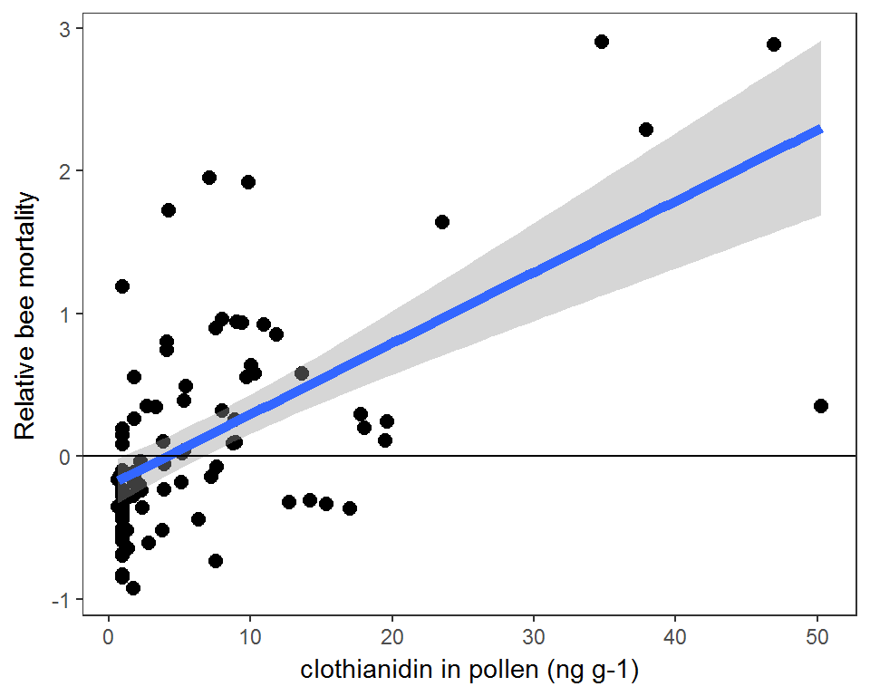

```
## -------------------------------------
##
##  Linear regression, thiamethoxam vs mortality:
##
## Call:
## lm(formula = as.formula(paste("mortality ~ ", interesting_neonics[i],
##     sep = "")), data = osu_covariate)
##
## Residuals:
##      Min       1Q   Median       3Q      Max
## -1.58329 -0.45042 -0.06344  0.23110  1.89358
##
## Coefficients:
##                 Estimate Std. Error t value Pr(>|t|)
## (Intercept)     -0.11535    0.09072  -1.272    0.207
## FP_thiamethoxam  0.07315    0.01498   4.882 4.73e-06 ***
## ---
## Signif. codes:  0 '***' 0.001 '**' 0.01 '*' 0.05 '.' 0.1 ' ' 1
##
## Residual standard error: 0.691 on 87 degrees of freedom
##   (11 observations deleted due to missingness)
## Multiple R-squared:  0.215,  Adjusted R-squared:  0.206
## F-statistic: 23.83 on 1 and 87 DF,  p-value: 4.727e-06
```

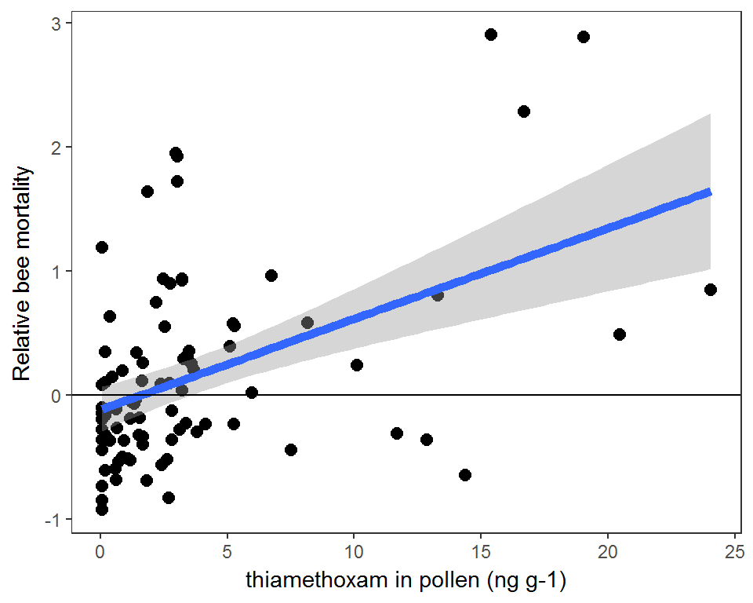

```
## -------------------------------------
##
##  Linear regression, clo + thi vs mortality:
##
## Call:
## lm(formula = as.formula(paste("mortality ~ ", interesting_neonics[i],
##     sep = "")), data = osu_covariate)
##
## Residuals:
##      Min       1Q   Median       3Q      Max
## -1.36983 -0.33084 -0.09338  0.31688  1.82155
##
## Coefficients:
##              Estimate Std. Error t value Pr(>|t|)
## (Intercept) -0.270069   0.083022  -3.253  0.00163 **
## FP_CT        0.039426   0.005069   7.777  1.4e-11 ***
## ---
## Signif. codes:  0 '***' 0.001 '**' 0.01 '*' 0.05 '.' 0.1 ' ' 1
##
## Residual standard error: 0.599 on 87 degrees of freedom
##   (11 observations deleted due to missingness)
## Multiple R-squared:  0.4101, Adjusted R-squared:  0.4033
## F-statistic: 60.49 on 1 and 87 DF,  p-value: 1.4e-11
```

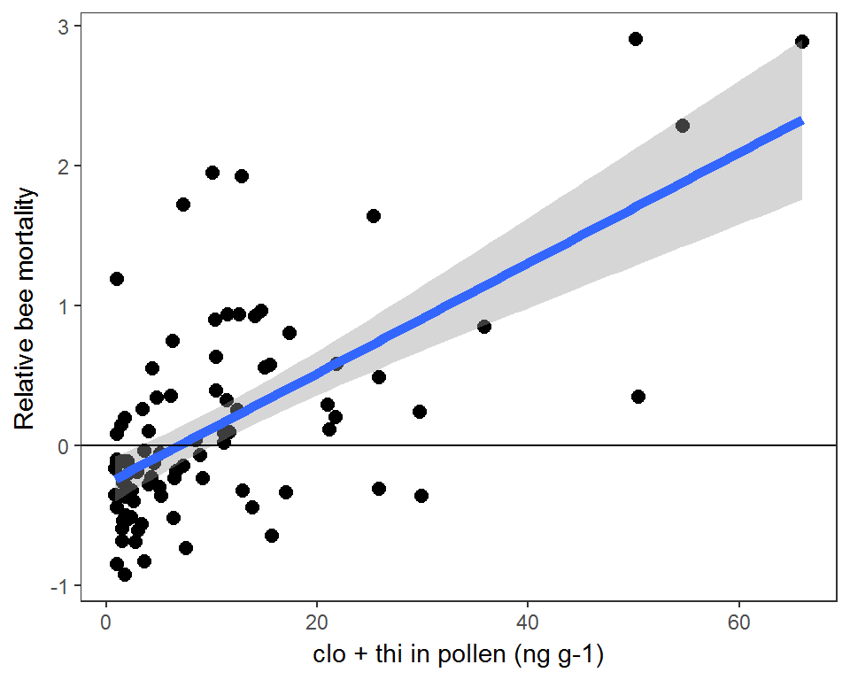

**Finding**: At times in May when clothianidin and thiamethoxam concentrations were greater, hives nearby had greater relative bee mortality rates.

#### Does this relationship between pollen concentrations and mortality hold if averaged over the whole month?

```
## -------------------------------------
##
##  Linear regression, Mean pollen clothianidin in May vs mortality:
##
## Call:
## lm(formula = as.formula(paste("daily_mort_may ~ ", interesting_neonics_site_m[i],
##     sep = "")), data = site_wide)
##
## Residuals:
##      Min       1Q   Median       3Q      Max
## -0.09114 -0.01022 -0.00037  0.02294  0.07680
##
## Coefficients:
##               Estimate Std. Error t value Pr(>|t|)
## (Intercept)  0.0879649  0.0699325   1.258    0.249
## mean_clo_may 0.0009438  0.0092737   0.102    0.922
##
## Residual standard error: 0.04949 on 7 degrees of freedom
## Multiple R-squared:  0.001477,   Adjusted R-squared:  -0.1412
## F-statistic: 0.01036 on 1 and 7 DF,  p-value: 0.9218
```

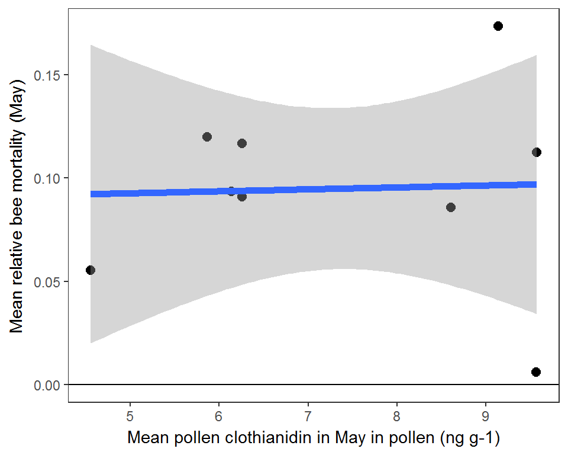

```
## -------------------------------------
##
##  Linear regression, Mean pollen thiamethoxam in May vs mortality:
##
## Call:
## lm(formula = as.formula(paste("daily_mort_may ~ ", interesting_neonics_site_m[i],
##     sep = "")), data = site_wide)
##
## Residuals:
##       Min        1Q    Median        3Q       Max
## -0.082081 -0.022824  0.008503  0.019151  0.071125
##
## Coefficients:
##              Estimate Std. Error t value Pr(>|t|)
## (Intercept)  0.066939   0.041630   1.608    0.152
## mean_thi_may 0.007318   0.010075   0.726    0.491
##
## Residual standard error: 0.04776 on 7 degrees of freedom
## Multiple R-squared:  0.07009,    Adjusted R-squared:  -0.06275
## F-statistic: 0.5276 on 1 and 7 DF,  p-value: 0.4912
```

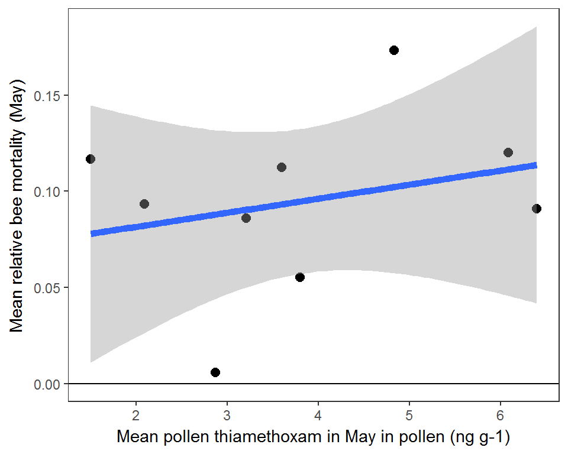

```
## -------------------------------------
##
##  Linear regression, Mean pollen clo + thi in May vs mortality:
##
## Call:
## lm(formula = as.formula(paste("daily_mort_may ~ ", interesting_neonics_site_m[i],
##     sep = "")), data = site_wide)
##
## Residuals:
##       Min        1Q    Median        3Q       Max
## -0.094501 -0.011852  0.008909  0.021649  0.066493
##
## Coefficients:
##             Estimate Std. Error t value Pr(>|t|)
## (Intercept) 0.047384   0.082001   0.578    0.581
## mean_ct_may 0.004261   0.007213   0.591    0.573
##
## Residual standard error: 0.04834 on 7 degrees of freedom
## Multiple R-squared:  0.04749,    Adjusted R-squared:  -0.08859
## F-statistic: 0.349 on 1 and 7 DF,  p-value: 0.5733
```

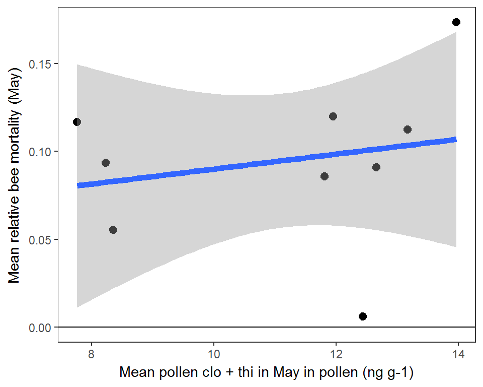

**Finding:** No significant relationship between mean pollen neonic concentrations through May and mean relative bee mortality

#### What about averaging just during the planting period?

```
## -------------------------------------
##
##  Linear regression, Mean pollen clothianidin during planting vs mortality:
##
## Call:
## lm(formula = as.formula(paste("daily_mortality_plt ~ ", interesting_neonics_site_p[i],
##     sep = "")), data = site_wide)
##
## Residuals:
##      Min       1Q   Median       3Q      Max
## -0.49427 -0.09994 -0.03168  0.10909  0.51756
##
## Coefficients:
##                   Estimate Std. Error t value Pr(>|t|)
## (Intercept)        0.28542    0.32952   0.866    0.415
## mean_clo_planting  0.03556    0.01957   1.816    0.112
##
## Residual standard error: 0.346 on 7 degrees of freedom
## Multiple R-squared:  0.3204, Adjusted R-squared:  0.2233
## F-statistic:   3.3 on 1 and 7 DF,  p-value: 0.1121
```

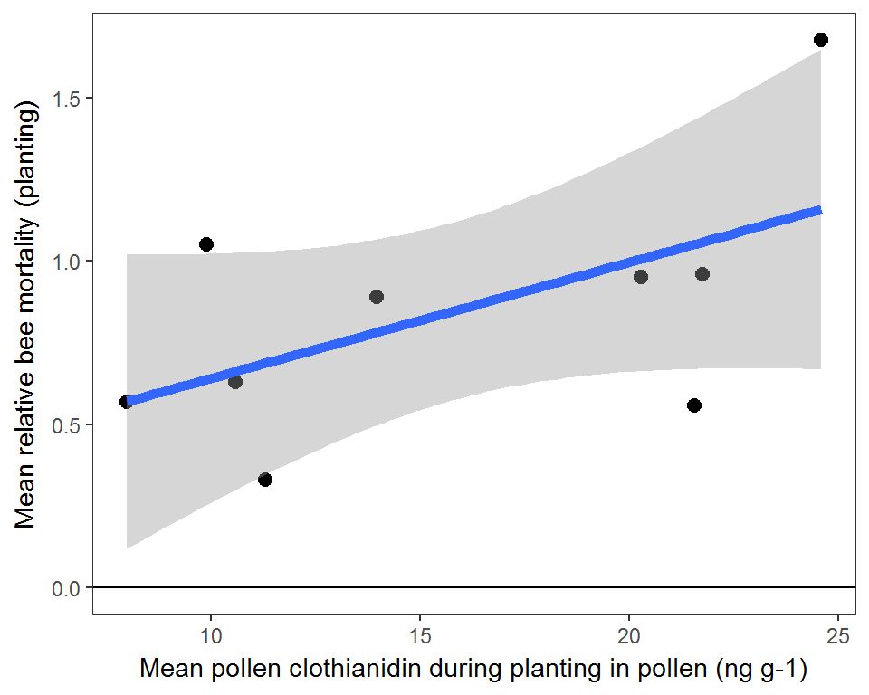

```
## -------------------------------------
##
##  Linear regression, Mean pollen thiamethoxam during planting vs mortality:
##
## Call:
## lm(formula = as.formula(paste("daily_mortality_plt ~ ", interesting_neonics_site_p[i],
##     sep = "")), data = site_wide)
##
## Residuals:
##      Min       1Q   Median       3Q      Max
## -0.68731 -0.14208  0.02189  0.12508  0.70239
##
## Coefficients:
##                   Estimate Std. Error t value Pr(>|t|)
## (Intercept)        0.60917    0.28243   2.157   0.0679 .
## mean_thi_planting  0.03576    0.03770   0.948   0.3745
## ---
## Signif. codes:  0 '***' 0.001 '**' 0.01 '*' 0.05 '.' 0.1 ' ' 1
##
## Residual standard error: 0.395 on 7 degrees of freedom
## Multiple R-squared:  0.1139, Adjusted R-squared:  -0.01272
## F-statistic: 0.8996 on 1 and 7 DF,  p-value: 0.3745
```

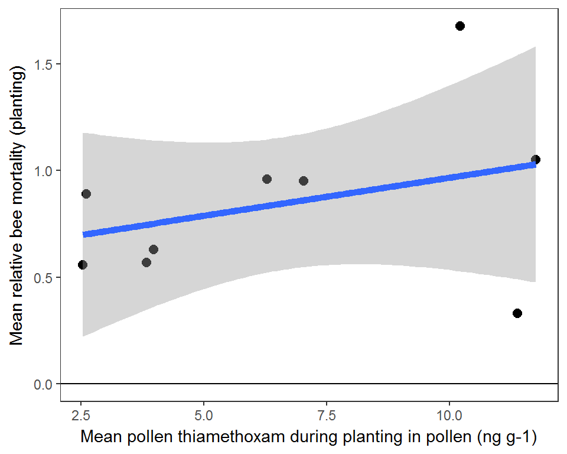

```
## -------------------------------------
##
##  Linear regression, Mean pollen clo + thi during planting vs mortality:
##
## Call:
## lm(formula = as.formula(paste("daily_mortality_plt ~ ", interesting_neonics_site_p[i],
##     sep = "")), data = site_wide)
##
## Residuals:
##      Min       1Q   Median       3Q      Max
## -0.52736 -0.08919  0.06398  0.23202  0.38719
##
## Coefficients:
##                  Estimate Std. Error t value Pr(>|t|)
## (Intercept)       0.04493    0.35993   0.125   0.9042
## mean_ct_planting  0.03577    0.01537   2.327   0.0528 .
## ---
## Signif. codes:  0 '***' 0.001 '**' 0.01 '*' 0.05 '.' 0.1 ' ' 1
##
## Residual standard error: 0.3151 on 7 degrees of freedom
## Multiple R-squared:  0.4362, Adjusted R-squared:  0.3557
## F-statistic: 5.416 on 1 and 7 DF,  p-value: 0.05282
```

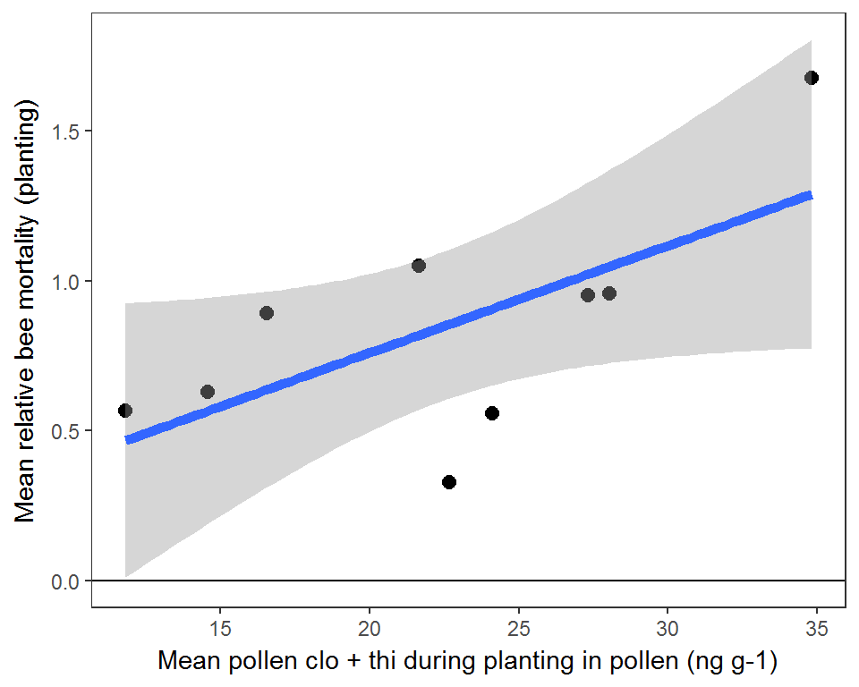

**Finding:** No significant relationship between mean pollen neonic concentrations through the planting period and mean relative bee mortality.

# Goal 1: Overall findings

- When we look within each sampling time point, greater clothianidin or thiamethoxam concentrations in pollen were associated with significantly elevated bee mortality.
- There is no significant relationship if we average neonic concentrations and bee mortality across May or the planting period.

# Goal 2: Neonic concentrations in pollen related to percent corn coverage nearby?

First, let’s try using each time point during May.

Our approach will be to model pollen neonic concentration as a factor of:

1. Percent corn nearby
2. Whether or not it was a planting period (yes/no)
3. Interaction between 1 and 2

If the interaction is significant, it will indicate that the effect of corn nearby on neonic conc. depends on whether it is during a planting period.

```
## -------------------------------------
##
##  Linear regression, FP_thiamethoxam vs percent corn:
##
## Call:
## lm(formula = as.formula(paste(interesting_neonics[i], "~ per_corn * planting",
##     sep = "")), data = osu_covariate)
##
## Residuals:
##     Min      1Q  Median      3Q     Max
## -7.7260 -2.2462 -1.4037  0.9041 18.2161
##
## Coefficients:
##                      Estimate Std. Error t value Pr(>|t|)
## (Intercept)           2.17362    1.25928   1.726    0.088 .
## per_corn              0.00682    0.04431   0.154    0.878
## plantingyes           0.98658    2.21587   0.445    0.657
## per_corn:plantingyes  0.11467    0.07987   1.436    0.155
## ---
## Signif. codes:  0 '***' 0.001 '**' 0.01 '*' 0.05 '.' 0.1 ' ' 1
##
## Residual standard error: 4.575 on 85 degrees of freedom
##   (11 observations deleted due to missingness)
## Multiple R-squared:  0.1634, Adjusted R-squared:  0.1339
## F-statistic: 5.534 on 3 and 85 DF,  p-value: 0.001613
##
## -------------------------------------
##
##  Linear regression, FP_clothianidin vs percent corn:
##
## Call:
## lm(formula = as.formula(paste(interesting_neonics[i], "~ per_corn * planting",
##     sep = "")), data = osu_covariate)
##
## Residuals:
##     Min      1Q  Median      3Q     Max
## -17.311  -2.523  -1.833   0.619  38.912
##
## Coefficients:
##                      Estimate Std. Error t value Pr(>|t|)
```

[output cut: 24 more lines]

```
## Coefficients:
##                      Estimate Std. Error t value Pr(>|t|)
## (Intercept)           4.75024    2.83501   1.676   0.0975 .
## per_corn              0.03535    0.09975   0.354   0.7240
## plantingyes           8.17981    4.98859   1.640   0.1048
## per_corn:plantingyes  0.28540    0.17982   1.587   0.1162
## ---
## Signif. codes:  0 '***' 0.001 '**' 0.01 '*' 0.05 '.' 0.1 ' ' 1
##
## Residual standard error: 10.3 on 85 degrees of freedom
##   (11 observations deleted due to missingness)
## Multiple R-squared:  0.3542, Adjusted R-squared:  0.3314
## F-statistic: 15.54 on 3 and 85 DF,  p-value: 3.824e-08
##
## -------------------------------------
```

**Finding:** There was no effect of percent corn nearby on clothianidin, thiamethoxam, or clo + thi.

#### What if we look at percent corn nearby versus *mean* neonic concentration over May (or planting period)?

For May:

```
## -------------------------------------
##
##  Linear regression, Mean pollen clothianidin in May vs percent corn:
##
## Call:
## lm(formula = as.formula(paste(interesting_neonics_site_m[i],
##     "~ per_corn", sep = "")), data = site_wide)
##
## Residuals:
##     Min      1Q  Median      3Q     Max
## -2.5416 -1.2268 -0.8326  2.0784  2.1434
##
## Coefficients:
##             Estimate Std. Error t value Pr(>|t|)
## (Intercept)  6.20031    1.73633   3.571  0.00909 **
## per_corn     0.04060    0.05796   0.700  0.50625
## ---
## Signif. codes:  0 '***' 0.001 '**' 0.01 '*' 0.05 '.' 0.1 ' ' 1
##
## Residual standard error: 1.95 on 7 degrees of freedom
## Multiple R-squared:  0.0655, Adjusted R-squared:  -0.068
## F-statistic: 0.4906 on 1 and 7 DF,  p-value: 0.5062
##
## -------------------------------------
##
##  Linear regression, Mean pollen thiamethoxam in May vs percent corn:
##
## Call:
## lm(formula = as.formula(paste(interesting_neonics_site_m[i],
##     "~ per_corn", sep = "")), data = site_wide)
##
## Residuals:
##     Min      1Q  Median      3Q     Max
## -2.4440 -0.9738 -0.2573  0.7739  2.5518
##
## Coefficients:
##             Estimate Std. Error t value Pr(>|t|)
## (Intercept)   3.5097     1.5906   2.207   0.0631 .
## per_corn      0.0111     0.0531   0.209   0.8403
## ---
```

[output cut: 15 more lines]

```
##    Min     1Q Median     3Q    Max
## -3.970 -2.464  1.170  1.689  1.856
##
## Coefficients:
##             Estimate Std. Error t value Pr(>|t|)
## (Intercept)  9.71001    2.17804   4.458  0.00294 **
## per_corn     0.05171    0.07271   0.711  0.50000
## ---
## Signif. codes:  0 '***' 0.001 '**' 0.01 '*' 0.05 '.' 0.1 ' ' 1
##
## Residual standard error: 2.446 on 7 degrees of freedom
## Multiple R-squared:  0.06738,    Adjusted R-squared:  -0.06586
## F-statistic: 0.5057 on 1 and 7 DF,  p-value: 0.5
##
## -------------------------------------
```

For planting period:

```
## -------------------------------------
##
##  Linear regression, Mean pollen clothianidin during planting vs percent corn:
##
## Call:
## lm(formula = as.formula(paste(interesting_neonics_site_p[i],
##     "~ per_corn", sep = "")), data = site_wide)
##
## Residuals:
##    Min     1Q Median     3Q    Max
## -6.779 -4.855 -3.667  5.167  9.189
##
## Coefficients:
##             Estimate Std. Error t value Pr(>|t|)
## (Intercept)  11.0018     5.6223   1.957   0.0912 .
## per_corn      0.1716     0.1877   0.914   0.3909
## ---
## Signif. codes:  0 '***' 0.001 '**' 0.01 '*' 0.05 '.' 0.1 ' ' 1
##
## Residual standard error: 6.314 on 7 degrees of freedom
## Multiple R-squared:  0.1067, Adjusted R-squared:  -0.02089
## F-statistic: 0.8363 on 1 and 7 DF,  p-value: 0.3909
##
## -------------------------------------
##
##  Linear regression, Mean pollen thiamethoxam during planting vs percent corn:
##
## Call:
## lm(formula = as.formula(paste(interesting_neonics_site_p[i],
##     "~ per_corn", sep = "")), data = site_wide)
##
## Residuals:
##     Min      1Q  Median      3Q     Max
## -5.3399 -1.7671 -0.5974  1.1009  5.8053
##
## Coefficients:
##             Estimate Std. Error t value Pr(>|t|)
## (Intercept)   3.3680     3.2672   1.031    0.337
## per_corn      0.1173     0.1091   1.076    0.318
##
```

[output cut: 13 more lines]

```
##     Min      1Q  Median      3Q     Max
## -9.0756 -5.2796  0.9205  5.0109  7.4216
##
## Coefficients:
##             Estimate Std. Error t value Pr(>|t|)
## (Intercept)  14.3698     6.0747   2.366   0.0499 *
## per_corn      0.2890     0.2028   1.425   0.1972
## ---
## Signif. codes:  0 '***' 0.001 '**' 0.01 '*' 0.05 '.' 0.1 ' ' 1
##
## Residual standard error: 6.822 on 7 degrees of freedom
## Multiple R-squared:  0.2249, Adjusted R-squared:  0.1141
## F-statistic: 2.031 on 1 and 7 DF,  p-value: 0.1972
##
## -------------------------------------
```

#### Finally, were mean neonic concentrations greater during the planting period compared to the monthly average?

We can use a simple t test:

```
## -------------------------------------
##
##  t-test, Mean pollen clothianidin during planting vs montly average:
##
##  Welch Two Sample t-test
##
## data:  site_wide[[interesting_neonics_site_p[i]]] and site_wide[[interesting_neonics_site_m[i]]]
## t = 3.8798, df = 9.4466, p-value = 0.003406
## alternative hypothesis: true difference in means is not equal to 0
## 95 percent confidence interval:
##   3.554758 13.328122
## sample estimates:
## mean of x mean of y
## 15.769556  7.328116
```

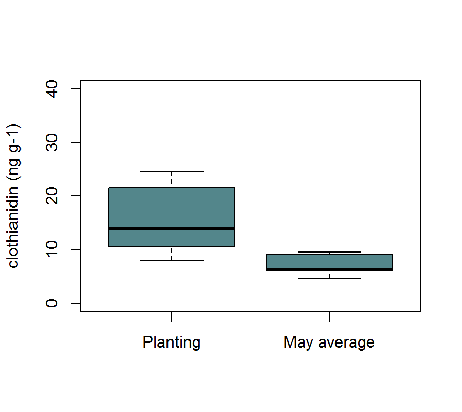

```
## -------------------------------------
##
##  t-test, Mean pollen thiamethoxam during planting vs montly average:
##
##  Welch Two Sample t-test
##
## data:  site_wide[[interesting_neonics_site_p[i]]] and site_wide[[interesting_neonics_site_m[i]]]
## t = 2.0728, df = 11.143, p-value = 0.06215
## alternative hypothesis: true difference in means is not equal to 0
## 95 percent confidence interval:
##  -0.1691312  5.7881251
## sample estimates:
## mean of x mean of y
##  6.627667  3.818170
```

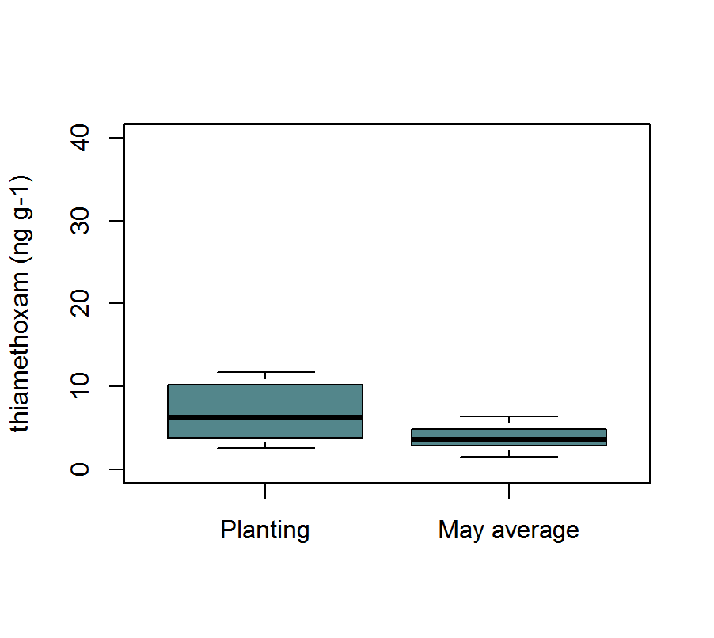

```
## -------------------------------------
##
##  t-test, Mean pollen clo + thi during planting vs montly average:
##
##  Welch Two Sample t-test
##
## data:  site_wide[[interesting_neonics_site_p[i]]] and site_wide[[interesting_neonics_site_m[i]]]
## t = 4.4266, df = 9.6902, p-value = 0.001383
## alternative hypothesis: true difference in means is not equal to 0
## 95 percent confidence interval:
##   5.563055 16.938818
## sample estimates:
## mean of x mean of y
##  22.39722  11.14629
##
## -------------------------------------
```

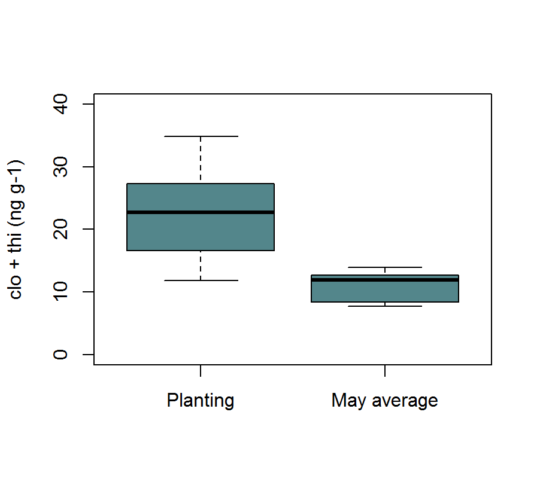

**Finding:** For clothianidin and clo + thi, mean concentrations were greater during the planting period than the monthly average. For thiamethoxam, the difference was borderline significant (p=0.06)

# Goal 2: Overall findings

- There were no significant effects of percent corn nearby on daily or mean neonic concentrations in pollen.
- But across all sites, mean clothianidin and clo + thi concentrations were significantly elevated during the planting period compared with the monthly average.

# Goal 3: Greater neonic exposure in May linked to long term consequences?

To address this question, we calculated relative changes in the six hive health variables:

- area of bees
- number of seams filled with bees
- area of capped brood
- area of open brood
- area of pollen
- area of nectar

We looked at relative changes between each sampling point, as well as for the entire study:

- interval 1: April - May
- interval 2: May - June
- interval 3: June - August
- total interval: April - August

Relative change (expressed as a %) was calculated as:

$Rel. change = \frac{final - initial}{initial}*100$

We also wanted to account for the idea that the negative effect of bees collecting neonic-contiminated pollen could be partially by the beneficial effect of increased food supply. Therefore, we included the relative change in hive pollen area as a potential covariate in our models.

So, for each hive health variable and interval combination, we fit a multiple linear regression model of the form:

*Relative change ~ (Mean clo + thi in May) + (relative change in pollen area over the same interval)*

If the pollen change covariate was not significant, we dropped the term and refit the model. Note: pollen covariate not applicable when relative change in pollen area was the main variable of interest.

#### Summary of significant effects:

**For interval 1 (April - May):**

Greater mean clo + thi in pollen in May was associated with:

- less rel. change in *bee area*
- less rel. change in *# of seams filled with bees*

**For interval 2 (May - June):**

**For interval 3 (June - August):**

**For total interval (April - August):**

No significant effects

#### Model summaries and plots of significant effects

```
##
## Call:
## lm(formula = bees_relchg_1 ~ mean_ct_may + pollen_relchg_1, data = site_wide)
##
## Residuals:
##    Min     1Q Median     3Q    Max
## -58.39 -16.55  12.06  14.08  32.96
##
## Coefficients:
##                 Estimate Std. Error t value Pr(>|t|)
## (Intercept)     162.3952    62.2946   2.607  0.04029 *
## mean_ct_may     -15.0056     5.3173  -2.822  0.03027 *
## pollen_relchg_1   0.4634     0.1080   4.291  0.00514 **
## ---
## Signif. codes:  0 '***' 0.001 '**' 0.01 '*' 0.05 '.' 0.1 ' ' 1
##
## Residual standard error: 34.8 on 6 degrees of freedom
## Multiple R-squared:  0.8466, Adjusted R-squared:  0.7954
## F-statistic: 16.55 on 2 and 6 DF,  p-value: 0.003613
```

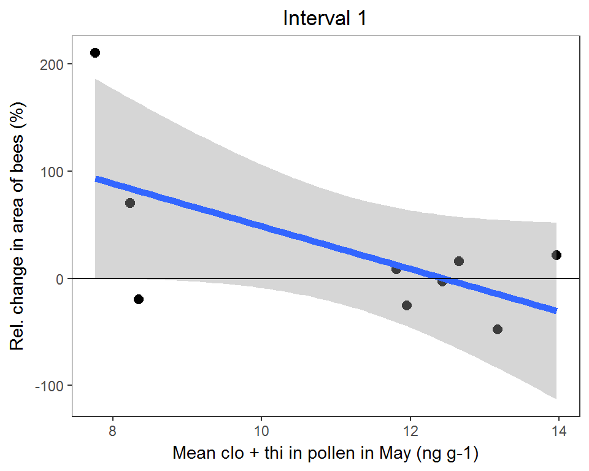

```
##
## Call:
## lm(formula = seams_relchg_1 ~ mean_ct_may, data = site_wide)
##
## Residuals:
##     Min      1Q  Median      3Q     Max
## -37.260 -25.107   3.869  27.699  30.666
##
## Coefficients:
##             Estimate Std. Error t value Pr(>|t|)
## (Intercept)  144.139     49.496   2.912   0.0226 *
## mean_ct_may  -10.394      4.354  -2.387   0.0484 *
## ---
## Signif. codes:  0 '***' 0.001 '**' 0.01 '*' 0.05 '.' 0.1 ' ' 1
##
## Residual standard error: 29.18 on 7 degrees of freedom
## Multiple R-squared:  0.4488, Adjusted R-squared:   0.37
## F-statistic: 5.699 on 1 and 7 DF,  p-value: 0.04837
```

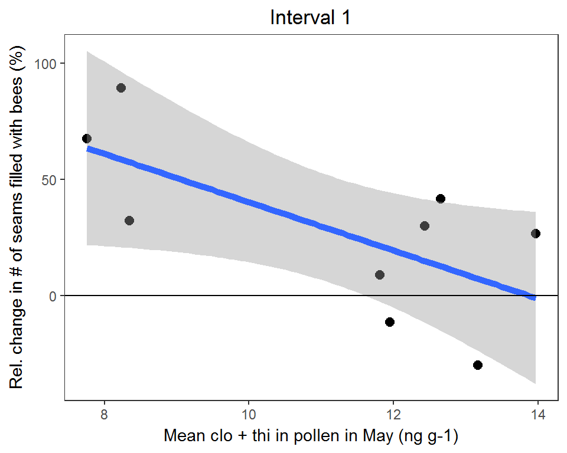

[output not shown]

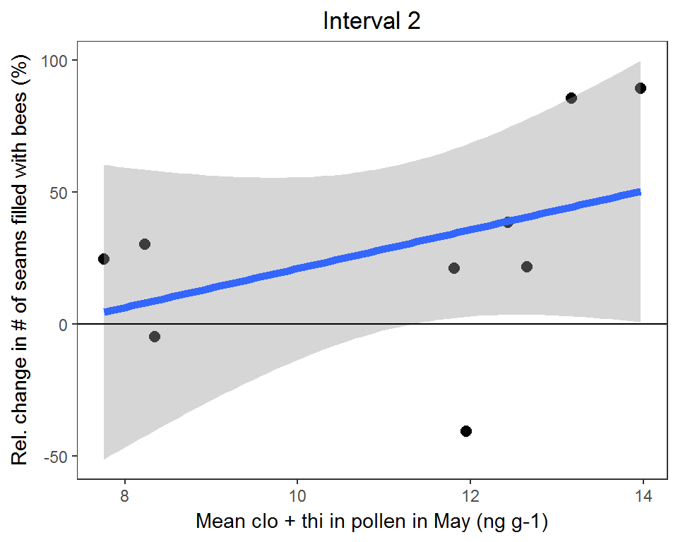

```
##
## Call:
## lm(formula = pollen_relchg_3 ~ mean_ct_may, data = site_wide)
##
## Residuals:
##    Min     1Q Median     3Q    Max
## -79.62 -35.32 -15.21  43.16  77.63
##
## Coefficients:
##             Estimate Std. Error t value Pr(>|t|)
## (Intercept) -164.837     92.696  -1.778   0.1186
## mean_ct_may   21.613      8.154   2.651   0.0329 *
## ---
## Signif. codes:  0 '***' 0.001 '**' 0.01 '*' 0.05 '.' 0.1 ' ' 1
##
## Residual standard error: 54.64 on 7 degrees of freedom
## Multiple R-squared:  0.5009, Adjusted R-squared:  0.4296
## F-statistic: 7.026 on 1 and 7 DF,  p-value: 0.03291
```

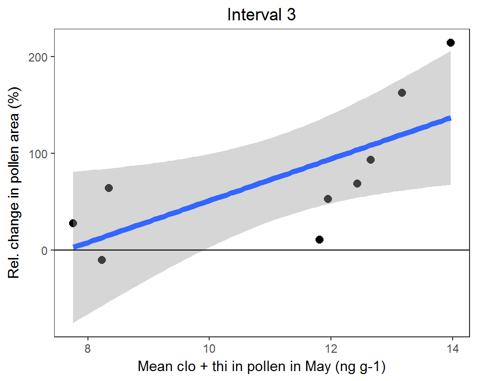

# Goal 3: Overall findings